# Chapter 25 - Visualization with Matplotlib

## Pair plots

Pair plots are a convenient way to explore potential correlations in your data when multiple variables are available.

We will use a `iris` dataset provided by Seaborn.

```python
iris = sns.load_dataset('iris')
iris.head()
```

|  | sepal_length | sepal_width | petal_length | petal_width | species |
| --- | --- | --- | --- | --- | --- |
| 0 | 5.1 | 3.5 | 1.4 | 0.2 | setosa |
| 1 | 4.9 | 3.0 | 1.4 | 0.2 | setosa |
| 2 | 4.7 | 3.2 | 1.3 | 0.2 | setosa |
| 3 | 4.6 | 3.1 | 1.5 | 0.2 | setosa |
| 4 | 5.0 | 3.6 | 1.4 | 0.2 | setosa |

The following will show a visualization of the relationships between each variable.

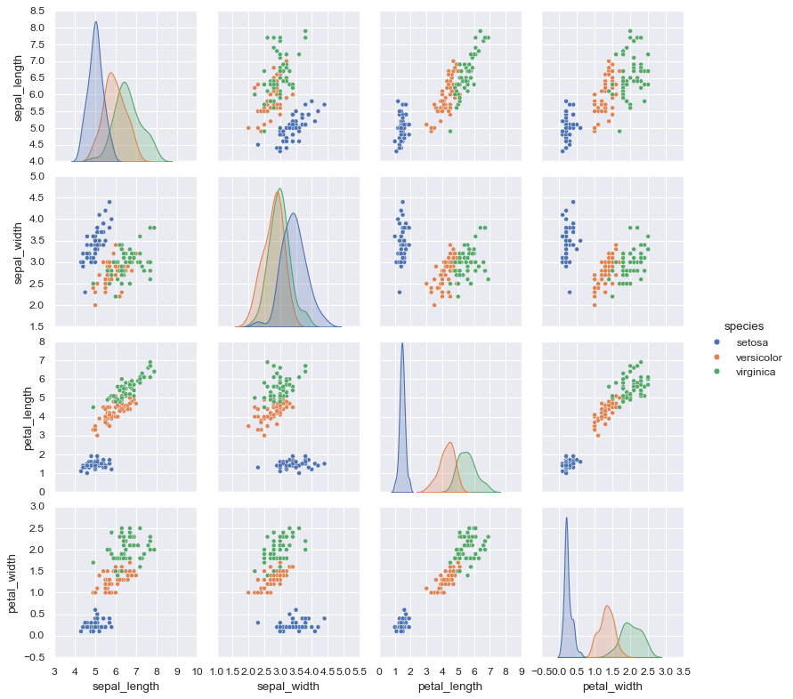

```python
sns.pairplot(iris, hue='species', height=2.5);
```

## Faceted Histograms

Faceted histograms break your data up into subsets based on categorical columns. Let us look at the `tips` dataset from Seaborn which describes tips received by male and female restaurant staff at lunch and at dinner.

```python
# Load dataset
tips = sns.load_dataset('tips')
tips.head()

# Calculate tip percentage
tips['tip_pct'] = 100*tips['tip']/tips['total_bill']
```

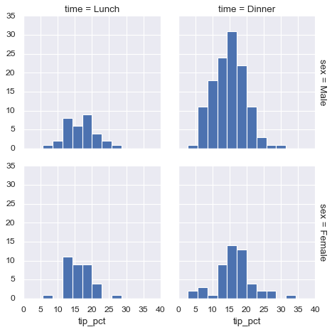

```python
grid = sns.FacetGrid(tips, row='sex', col='time', margin_titles=True)  # Create a FacetGrid where rows correspond to 'sex' and columns are 'time' (lunch/dinner)
grid.map(plt.hist, 'tip_pct', bins=np.linspace(0, 40, 15));
```

## Categorical plots

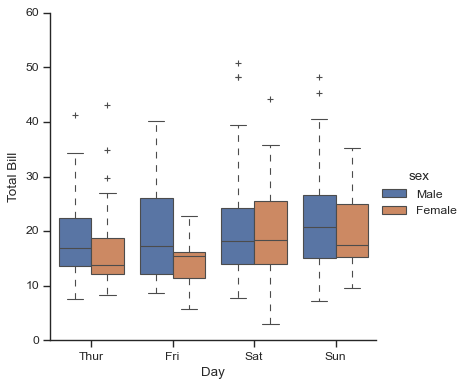

```python
with sns.axes_style(style='ticks'):
            g = sns.catplot(x="day", y="total_bill", hue="sex",
                            data=tips, kind="box")
            g.set_axis_labels("Day", "Total Bill");
```

## Joint distributions

Joint plots display the relation between two distributions in the data.

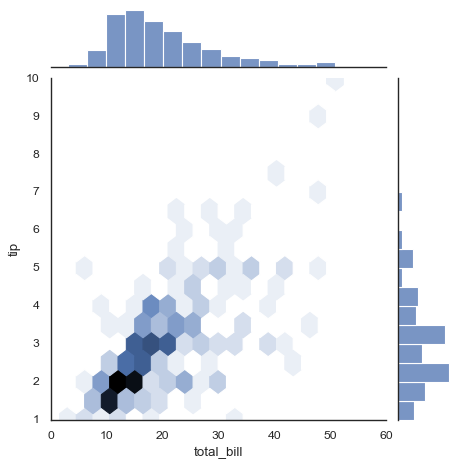

```python
with sns.axes_style('white'):
             sns.jointplot(x="total_bill", y="tip", data=tips, kind='hex')
```

Joint plot can also do regression.

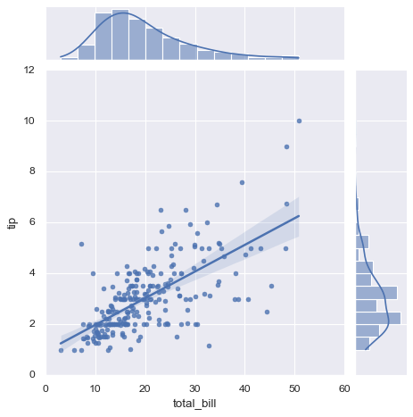

```python
sns.jointplot(x="total_bill", y="tip", data=tips, kind='reg');
```

# Bar plots

```python
# Loading the planets dataset

planets = sns.load_dataset('planets')
planets.head()
```

|  | method | number | orbital_period | mass | distance | year |
| --- | --- | --- | --- | --- | --- | --- |
| 0 | Radial Velocity | 1 | 269.300 | 7.10 | 77.40 | 2006 |
| 1 | Radial Velocity | 1 | 874.774 | 2.21 | 56.95 | 2008 |
| 2 | Radial Velocity | 1 | 763.000 | 2.60 | 19.84 | 2011 |
| 3 | Radial Velocity | 1 | 326.030 | 19.40 | 110.62 | 2007 |
| 4 | Radial Velocity | 1 | 516.220 | 10.50 | 119.47 | 2009 |

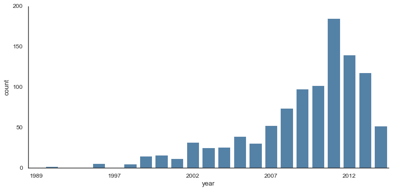

```python
with sns.axes_style('white'):
             g = sns.catplot(x="year", data=planets, aspect=2,
                             kind="count", color='steelblue')
             g.set_xticklabels(step=5)
```

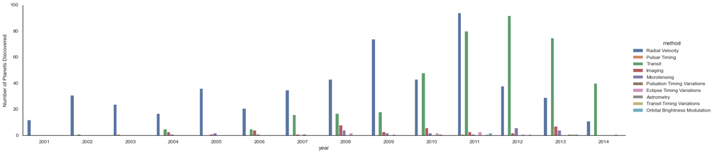

```python
with sns.axes_style('white'):
             g = sns.catplot(x="year", data=planets, aspect=4.0, kind='count',
                             hue='method', order=range(2001, 2015))
             g.set_ylabels('Number of Planets Discovered')
```

## Exploring the Taxis dataset

```python
taxis = sns.load_dataset('taxis')
taxis['pickup'] = pd.to_datetime(taxis['pickup'])
taxis.head()
```

|  | pickup | dropoff | passengers | distance | fare | tip | tolls | total | color | payment | pickup_zone | dropoff_zone | pickup_borough | dropoff_borough |
| --- | --- | --- | --- | --- | --- | --- | --- | --- | --- | --- | --- | --- | --- | --- |
| 0 | 2019-03-23 20:21:09 | 2019-03-23 20:27:24 | 1 | 1.60 | 7.0 | 2.15 | 0.0 | 12.95 | yellow | credit card | Lenox Hill West | UN/Turtle Bay South | Manhattan | Manhattan |
| 1 | 2019-03-04 16:11:55 | 2019-03-04 16:19:00 | 1 | 0.79 | 5.0 | 0.00 | 0.0 | 9.30 | yellow | cash | Upper West Side South | Upper West Side South | Manhattan | Manhattan |
| 2 | 2019-03-27 17:53:01 | 2019-03-27 18:00:25 | 1 | 1.37 | 7.5 | 2.36 | 0.0 | 14.16 | yellow | credit card | Alphabet City | West Village | Manhattan | Manhattan |
| 3 | 2019-03-10 01:23:59 | 2019-03-10 01:49:51 | 1 | 7.70 | 27.0 | 6.15 | 0.0 | 36.95 | yellow | credit card | Hudson Sq | Yorkville West | Manhattan | Manhattan |
| 4 | 2019-03-30 13:27:42 | 2019-03-30 13:37:14 | 3 | 2.16 | 9.0 | 1.10 | 0.0 | 13.40 | yellow | credit card | Midtown East | Yorkville West | Manhattan | Manhattan |

There are two cab colors in this data, *green* and *yellow*. Which group of taxis travels more? Which color makes the most revenue? Let us look at some plots.

First, we will look at the distribution of `distance` for yellow and green taxis.

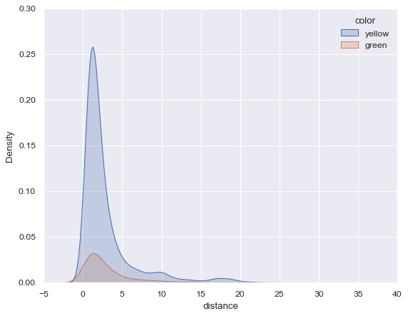

```python
sns.kdeplot(data=taxis, x='distance', fill=True, hue='color');
```

There are way more yellow cabs than green ones. The distribution shows that difference. By default, the distributions are normalized jointly. If you are interested in investigating the proportion of yellow and green taxis independently, you can set the `common_norm` argument to `False`.

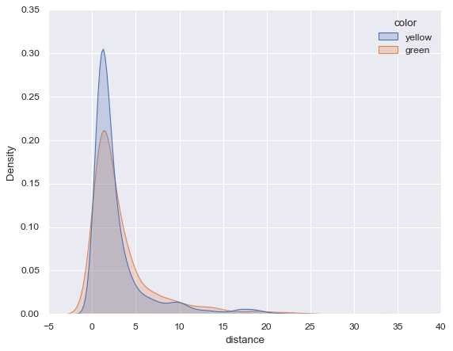

```python
sns.kdeplot(data=taxis, x='distance', fill=True, hue='color', common_norm=False);
```

Let us check if the tip and total fare correlate by using a jointplot.

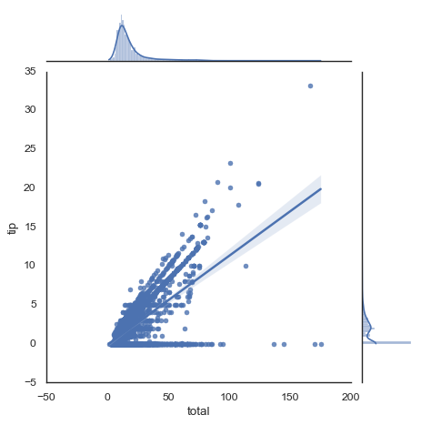

```python
with sns.axes_style('white'):
             sns.jointplot(x="total", y="tip", data=taxis, kind='reg')
```

Let us plot the total fare per pickup borough for each taxi color in a box plot.

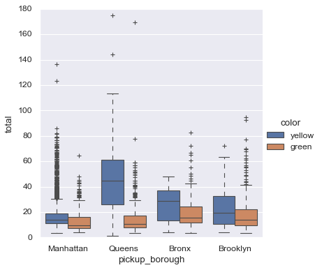

```python
sns.catplot(data=taxis, x='pickup_borough', hue='color', y='total', kind='box');
```

Now let us look at several variables paired up to identify possible correlations using `PairGrid`.

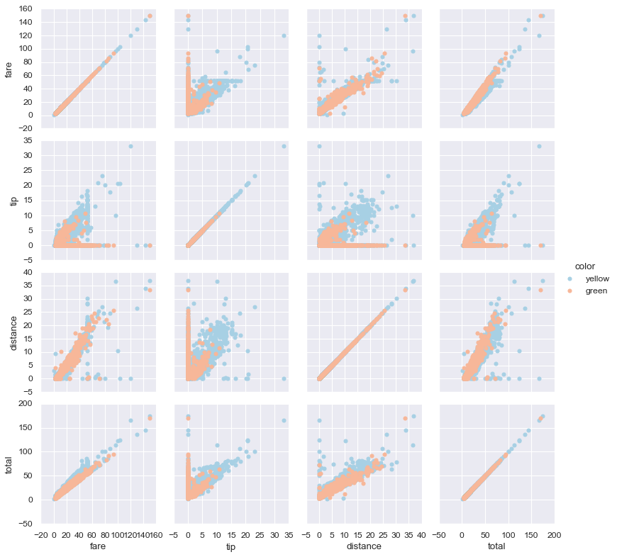

```python
g = sns.PairGrid(taxis, vars=['fare', 'tip', 'distance', 'total'],
                          hue='color', palette='RdBu_r')
g.map(plt.scatter)
g.add_legend();
```